# Water Quality Classification (2012-2024)

**Final Project — Machine Learning**

This notebook presents the exploratory analysis and AI prediction of the groundwater quality monitoring dataset from Mexico, published by CONAGUA and covering the period 2012–2024. The EDA aims to:

- Understand the structure, coverage, and quality of the data.
- Identify the behavior of physicochemical and microbiological parameters.
- Justify the preprocessing decisions applied prior to modeling.
- Explore the target variable (`SEMÁFORO`) and its relationship with the predictors.

This analysis logically precedes the predictive modeling stage (Decision Tree, Logistic Regression, and SVM) documented in the complementary notebook.

## 0. Imports & Style

```python
import pandas as pd
import numpy as np
import matplotlib.pyplot as plt
import seaborn as sns
import joblib
from pathlib import Path
import math

COLORS_SEMAFORO = {'VERDE': '#2ecc71', 'AMARILLO': '#f1c40f', 'ROJO': '#e74c3c'}
```

## 1. Load and Structure of the Dataset

The file contains three sheets: the main sheet `CASUB_12-2024` with the monitoring data, a data dictionary sheet, and a sheet with classification scales by parameter. We worked exclusively with the main sheet.

```python
# Importing the 'drive' module from 'google.colab' to interact with Google Drive
from google.colab import drive

# Mounting Google Drive to access files stored in it
drive.mount('/content/drive')
```

```python
# Load the groundwater water quality dataset (2012–2024) from the "data" folder into a pandas DataFrame
df = pd.read_excel('/content/sample_data/Calidad_del_Agua_Subterr_nea_p_2012-2024_15082025.xlsx')
```

```python
df.head()
```

|  | CLAVE SITIO | SITIO | ORGANISMO _DE_CUENCA | ESTADO | MUNICIPIO | ACUIFERO | SUBTIPO | LONGITUD | LATITUD | PERIODO | ... | HG_TOT_mg/L | CALIDAD_HG | PB_TOT_mg/L | CALIDAD_PB | MN_TOT_mg/L | CALIDAD_MN | FE_TOT_mg/L | CALIDAD_FE | SEMÁFORO | CONTAMINANTES |
| --- | --- | --- | --- | --- | --- | --- | --- | --- | --- | --- | --- | --- | --- | --- | --- | --- | --- | --- | --- | --- | --- |
| 0 | BROTE CARMINA 3 | CARMINA 3 BROTE | RÍO BRAVO | COAHUILA DE ZARAGOZA | ACUÑA | PRESA LA AMISTAD | BROTE | -101.07538 | 29.44255 | 2012-2024 | ... | <0.000201289 | Potable - Excelente | <0.00154 | Potable - Excelente | 0.032 | Potable - Excelente | 0.011 | Potable - Excelente | AMARILLO | DT, |
| 1 | CAZEPA-1 | POZO SAN FERNANDO 1 | CUENCAS CENTRALES DEL NORTE | DURANGO | LERDO | VILLA JUAREZ | POZO | -103.53551 | 25.50971 | 2012-2024 | ... | 0.000116 | Potable - Excelente | <0.00154 | Potable - Excelente | <0.00021 | Potable - Excelente | 0.00425 | Potable - Excelente | VERDE | NaN |
| 2 | CAZEPA-10 | POZO EL HUARACHE | CUENCAS CENTRALES DEL NORTE | DURANGO | LERDO | PRINCIPAL-REGION LAGUNERA | POZO | -103.49819 | 25.52886 | 2012-2024 | ... | <0.0002012945 | Potable - Excelente | 0.00827 | Potable - Excelente | 0.01315 | Potable - Excelente | 0.19075 | Potable - Excelente | VERDE | NaN |
| 3 | CAZEPA-11 | POZO LAS AURAS | CUENCAS CENTRALES DEL NORTE | DURANGO | LERDO | PRINCIPAL-REGION LAGUNERA | POZO | -103.51438 | 25.54889 | 2012-2024 | ... | <0.0002012945 | Potable - Excelente | <0.00154 | Potable - Excelente | 0.001105 | Potable - Excelente | 0.01655 | Potable - Excelente | VERDE | NaN |
| 4 | CAZEPA-2 | POZO SAN FERNANDO 2 | CUENCAS CENTRALES DEL NORTE | DURANGO | LERDO | VILLA JUAREZ | POZO | -103.53953 | 25.50946 | 2012-2024 | ... | <0.0002012945 | Potable - Excelente | <0.00154 | Potable - Excelente | 0.1047 | Potable - Excelente | 0.0045 | Potable - Excelente | VERDE | NaN |

5 rows × 41 columns

```python
# Data type and null-values
df.info()
```

```
<class 'pandas.core.frame.DataFrame'>
RangeIndex: 2728 entries, 0 to 2727
Data columns (total 41 columns):
 #   Column                Non-Null Count  Dtype
---  ------                --------------  -----
 0   CLAVE SITIO           2728 non-null   object
 1   SITIO                 2728 non-null   object
 2   ORGANISMO _DE_CUENCA  2728 non-null   object
 3   ESTADO                2728 non-null   object
 4   MUNICIPIO             2728 non-null   object
 5   ACUIFERO              2728 non-null   object
 6   SUBTIPO               2728 non-null   object
 7   LONGITUD              2728 non-null   float64
 8   LATITUD               2728 non-null   float64
 9   PERIODO               2728 non-null   object
```

[output cut: 33 more lines]

```python
df["SEMÁFORO"].unique()
```

```
array(['AMARILLO', 'VERDE', 'ROJO'], dtype=object)
```

### 1.1 Features Description & Target Description

The dataset includes variables of three types:

| Type | Variables |
| --- | --- |
| **Georeferencing** | `CLAVE SITIO`, `SITIO`, `ORGANISMO_DE_CUENCA`, `ESTADO`, `MUNICIPIO`, `ACUIFERO`, `SUBTIPO`, `LONGITUD`, `LATITUD` |
| **Physicochemical and microbiological parameters** (numerical) | Alkalinity, Conductivity, TDS, Fluorides, Hardness, Fecal Coliforms, Nitrates, Arsenic, Cadmium, Chromium, Mercury, Lead, Manganese, Iron |
| **Classification variables** | `CALIDAD_*` (one per parameter), `SEMÁFORO`, `CONTAMINANTES` |

The target variable for modeling is `SEMÁFORO`, which integrates all indicators into a three-level classification: **GREEN** (good water quality), **YELLOW** (intermediate quality), and **RED** (contaminated or unsafe water).

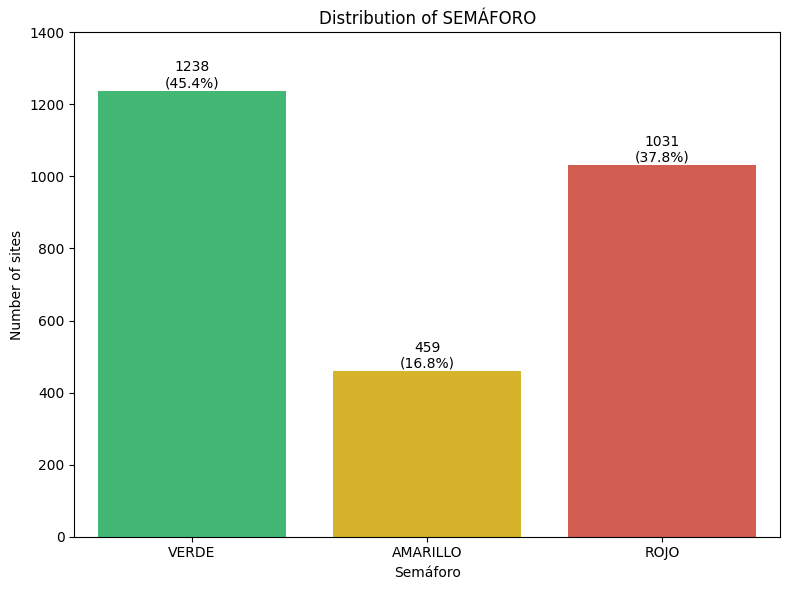

```python
"""Bar Plot Distribution of the "SEMÁFORO" Target Variable"""
counts = df["SEMÁFORO"].value_counts().reindex(['VERDE', 'AMARILLO', 'ROJO'])
COLORS_SEMAFORO = {'VERDE': '#2ecc71', 'AMARILLO': '#f1c40f', 'ROJO': '#e74c3c'}

# Bar plot
plt.figure(figsize=(8, 6))
bar = sns.barplot(x=counts.index, y=counts.values, hue=counts.index, palette=COLORS_SEMAFORO, legend=False)

# Add text labels with count and percentage
total = counts.sum()
for i, (category, count) in enumerate(counts.items()):
    percentage = (count / total) * 100
    bar.text(i, count + 1, f'{count}\n({percentage:.1f}%)', ha='center', va='bottom', fontweight='normal')

# Set y-axis limits
bar.set_ylim(0, 1400)

plt.xlabel('Semáforo')
plt.ylabel('Number of sites')
plt.title('Distribution of SEMÁFORO')
plt.tight_layout()
plt.show()
```

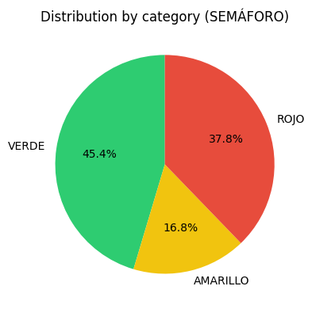

```python
"""Pie chart to see the total distribution of SEMÁFORO with their percentage (%)"""
plt.figure(figsize=(6, 4))
colors = [COLORS_SEMAFORO[category] for category in counts.index]
plt.pie(counts.values, labels=counts.index, autopct='%1.1f%%', colors=colors, startangle=90)
plt.title('Distribution by category (SEMÁFORO)')
plt.tight_layout()
plt.show()
```

The `YELLOW` class represents only 16.8% of the total, which disbalances the classes to be predicted in classification models.

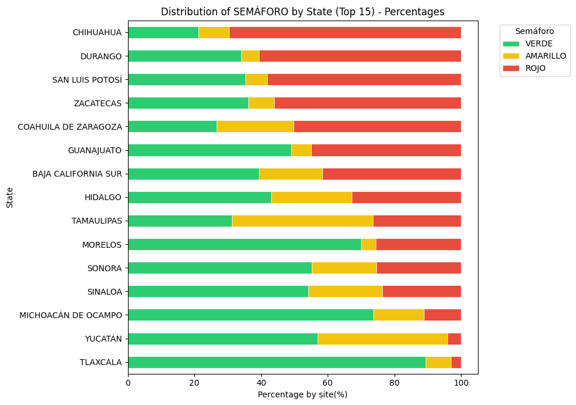

```python
"""Stacked Bar Plot to See the Top 15 States and Their Distribution of Water Quality"""
top_states = df['ESTADO'].value_counts().head(15).index
df_top = df[df['ESTADO'].isin(top_states)].copy()

ORDEN_SEMAFORO = ['VERDE', 'AMARILLO', 'ROJO']

# Crosstab to get counts by ESTADO and SEMÁFORO
pivot = pd.crosstab(df_top['ESTADO'], df_top['SEMÁFORO'])

# Make columns appear in order
for col in ORDEN_SEMAFORO:
    if col not in pivot.columns:
        pivot[col] = 0
pivot = pivot[ORDEN_SEMAFORO]

# Calculate percentages
pivot_pct = pivot.div(pivot.sum(axis=1), axis=0) * 100
pivot_pct = pivot_pct.sort_values('ROJO', ascending=True)

# Stacked horizontal bar plot
fig, ax = plt.subplots(figsize=(10, 7))
pivot_pct.plot(
    kind='barh', stacked=True, ax=ax,
    color=[COLORS_SEMAFORO[c] for c in ['VERDE', 'AMARILLO', 'ROJO']],
    edgecolor='white', linewidth=0.5
)

plt.xlabel('Percentage by site(%)')
plt.ylabel('State')
plt.title('Distribution of SEMÁFORO by State (Top 15) - Percentages')
plt.legend(title='Semáforo', bbox_to_anchor=(1.05, 1), loc='upper left')
plt.tight_layout()
plt.show()
```

## 2. Data Quality

Before analyzing the numerical variables, it is necessary to quantify two issues affecting this dataset:

```python
features= [
    'ALC_mg/L', 'SDT_mg/L', 'FLUORUROS_mg/L', 'DUR_mg/L',
    'COLI_FEC_NMP/100_mL', 'N_NO3_mg/L', 'AS_TOT_mg/L',
    'CD_TOT_mg/L', 'CR_TOT_mg/L', 'HG_TOT_mg/L',
    'PB_TOT_mg/L', 'MN_TOT_mg/L', 'FE_TOT_mg/L'
]

df[features].isnull().sum().sum()
```

```
np.int64(4450)
```

```python
df[features].isnull().sum()
```

|  | 0 |
| --- | --- |
| ALC_mg/L | 91 |
| SDT_mg/L | 90 |
| FLUORUROS_mg/L | 213 |
| DUR_mg/L | 63 |
| COLI_FEC_NMP/100_mL | 500 |
| N_NO3_mg/L | 105 |
| AS_TOT_mg/L | 296 |
| CD_TOT_mg/L | 554 |
| CR_TOT_mg/L | 553 |
| HG_TOT_mg/L | 498 |
| PB_TOT_mg/L | 551 |
| MN_TOT_mg/L | 472 |
| FE_TOT_mg/L | 464 |

**dtype:** int64

```python
df[features].info()
```

```
<class 'pandas.core.frame.DataFrame'>
RangeIndex: 2728 entries, 0 to 2727
Data columns (total 13 columns):
 #   Column               Non-Null Count  Dtype
---  ------               --------------  -----
 0   ALC_mg/L             2637 non-null   object
 1   SDT_mg/L             2638 non-null   object
 2   FLUORUROS_mg/L       2515 non-null   object
 3   DUR_mg/L             2665 non-null   object
 4   COLI_FEC_NMP/100_mL  2228 non-null   object
 5   N_NO3_mg/L           2623 non-null   object
 6   AS_TOT_mg/L          2432 non-null   object
 7   CD_TOT_mg/L          2174 non-null   object
 8   CR_TOT_mg/L          2175 non-null   object
 9   HG_TOT_mg/L          2230 non-null   object
 10  PB_TOT_mg/L          2177 non-null   object
 11  MN_TOT_mg/L          2256 non-null   object
 12  FE_TOT_mg/L          2264 non-null   object
dtypes: object(13)
memory usage: 277.2+ KB
```

```python
# Count rows with "<" before cleaning
less_than_counts = pd.Series(dtype=int)
for col in features:
    count = df[col].astype(str).str.startswith('<').sum()
    less_than_counts[col] = count

print("Count of values starting with '<':")
print(less_than_counts)
print(f"\nTotal: {less_than_counts.sum()}")
```

```
Count of values starting with '<':
ALC_mg/L                  4
SDT_mg/L                  2
FLUORUROS_mg/L           39
DUR_mg/L                 21
COLI_FEC_NMP/100_mL     897
N_NO3_mg/L               98
AS_TOT_mg/L            1008
CD_TOT_mg/L            2021
CR_TOT_mg/L             946
HG_TOT_mg/L            1155
PB_TOT_mg/L            1712
MN_TOT_mg/L             573
FE_TOT_mg/L             222
dtype: int64

Total: 8698
```

```python
df[features].head(5)
```

|  | ALC_mg/L | SDT_mg/L | FLUORUROS_mg/L | DUR_mg/L | COLI_FEC_NMP/100_mL | N_NO3_mg/L | AS_TOT_mg/L | CD_TOT_mg/L | CR_TOT_mg/L | HG_TOT_mg/L | PB_TOT_mg/L | MN_TOT_mg/L | FE_TOT_mg/L |
| --- | --- | --- | --- | --- | --- | --- | --- | --- | --- | --- | --- | --- | --- |
| 0 | 139.7 | 562.4 | 0.82 | 505.8 | 97 | 0.591 | <0.0015 | <0.00130148 | <0.0012 | <0.000201289 | <0.00154 | 0.032 | 0.011 |
| 1 | 148.645 | 184.6 | 0.52 | 132 | <10 | 0.315762 | 0.011667 | <0.00130124 | <0.0012 | 0.000116 | <0.00154 | <0.00021 | 0.00425 |
| 2 | 205.02 | 378 | 0.43 | 230 | 10 | 3.182 | 0.012767 | <0.00130124 | 0.0023 | <0.0002012945 | 0.00827 | 0.01315 | 0.19075 |
| 3 | 229.14 | 322 | 0.5 | 221.7114 | <10 | 3.843 | 0.012533 | <0.00130124 | 0.0021 | <0.0002012945 | <0.00154 | 0.001105 | 0.01655 |
| 4 | 168.4 | 239.6 | 0.566 | 152 | <10 | 0.156885 | 0.012567 | <0.00130124 | 0.00175 | <0.0002012945 | <0.00154 | 0.1047 | 0.0045 |

### Observations on Data Quality

- **Basic parameters** (alkalinity, conductivity, TDS, hardness) have less than 5% missing values — they are the most reliable for modeling.
- **Fecal coliforms** have ~18% missing values, which limits their usefulness as a predictor.
- **Heavy metals** (Cd, Cr, Hg, Pb) show between 18% and 21% missing data, along with an additional proportion of values below the detection limit.
- **Imputation decision:** Missing values are imputed using the mean of each variable. For censored values (`<X`), a value of 0 is assigned, which is a conservative convention assuming the lowest possible concentration.

## 3. Cleaning and Preparation for Numerical Analysis

We converted the numerical columns that were stored as text, handling the censored values.

```python
# Function to clean values
def clean_numeric(val):
    if pd.isna(val):
        return np.nan
    val = str(val).strip()
    if val.startswith('<'):
        return 0
    try:
        return float(val)
    except ValueError:
        return np.nan

# Apply to all features
for col in features:
    df[col] = df[col].apply(clean_numeric).astype(float)  # force float

# Fill missing values with column means
for col in features:
    df[col] = df[col].fillna(df[col].mean())

# Quick check
print("Missing values after cleaning:", df[features].isna().sum().sum())
print(df[features].dtypes)
```

```
Missing values after cleaning: 0
ALC_mg/L               float64
SDT_mg/L               float64
FLUORUROS_mg/L         float64
DUR_mg/L               float64
COLI_FEC_NMP/100_mL    float64
N_NO3_mg/L             float64
AS_TOT_mg/L            float64
CD_TOT_mg/L            float64
CR_TOT_mg/L            float64
HG_TOT_mg/L            float64
PB_TOT_mg/L            float64
MN_TOT_mg/L            float64
FE_TOT_mg/L            float64
dtype: object
```

```python
# Count rows with "<" after cleaning
less_than_counts = pd.Series(dtype=int)
for col in features:
    count = df[col].astype(str).str.startswith('<').sum()
    less_than_counts[col] = count

print("Count of values starting with '<':")
print(less_than_counts)
print(f"\nTotal: {less_than_counts.sum()}")
```

```
Count of values starting with '<':
ALC_mg/L               0
SDT_mg/L               0
FLUORUROS_mg/L         0
DUR_mg/L               0
COLI_FEC_NMP/100_mL    0
N_NO3_mg/L             0
AS_TOT_mg/L            0
CD_TOT_mg/L            0
CR_TOT_mg/L            0
HG_TOT_mg/L            0
PB_TOT_mg/L            0
MN_TOT_mg/L            0
FE_TOT_mg/L            0
dtype: int64

Total: 0
```

```python
df = df[features + ['SEMÁFORO', 'CONTAMINANTES', 'ESTADO']].copy()
```

```python
df.isnull().sum()
```

|  | 0 |
| --- | --- |
| ALC_mg/L | 0 |
| SDT_mg/L | 0 |
| FLUORUROS_mg/L | 0 |
| DUR_mg/L | 0 |
| COLI_FEC_NMP/100_mL | 0 |
| N_NO3_mg/L | 0 |
| AS_TOT_mg/L | 0 |
| CD_TOT_mg/L | 0 |
| CR_TOT_mg/L | 0 |
| HG_TOT_mg/L | 0 |
| PB_TOT_mg/L | 0 |
| MN_TOT_mg/L | 0 |
| FE_TOT_mg/L | 0 |
| SEMÁFORO | 0 |
| CONTAMINANTES | 1238 |
| ESTADO | 0 |

**dtype:** int64

```python
df.info()
```

```
<class 'pandas.core.frame.DataFrame'>
RangeIndex: 2728 entries, 0 to 2727
Data columns (total 16 columns):
 #   Column               Non-Null Count  Dtype
---  ------               --------------  -----
 0   ALC_mg/L             2728 non-null   float64
 1   SDT_mg/L             2728 non-null   float64
 2   FLUORUROS_mg/L       2728 non-null   float64
 3   DUR_mg/L             2728 non-null   float64
 4   COLI_FEC_NMP/100_mL  2728 non-null   float64
 5   N_NO3_mg/L           2728 non-null   float64
 6   AS_TOT_mg/L          2728 non-null   float64
 7   CD_TOT_mg/L          2728 non-null   float64
 8   CR_TOT_mg/L          2728 non-null   float64
 9   HG_TOT_mg/L          2728 non-null   float64
 10  PB_TOT_mg/L          2728 non-null   float64
 11  MN_TOT_mg/L          2728 non-null   float64
 12  FE_TOT_mg/L          2728 non-null   float64
 13  SEMÁFORO             2728 non-null   object
 14  CONTAMINANTES        1490 non-null   object
 15  ESTADO               2728 non-null   object
dtypes: float64(13), object(3)
memory usage: 341.1+ KB
```

```python
df.head()
```

|  | ALC_mg/L | SDT_mg/L | FLUORUROS_mg/L | DUR_mg/L | COLI_FEC_NMP/100_mL | N_NO3_mg/L | AS_TOT_mg/L | CD_TOT_mg/L | CR_TOT_mg/L | HG_TOT_mg/L | PB_TOT_mg/L | MN_TOT_mg/L | FE_TOT_mg/L | SEMÁFORO | CONTAMINANTES | ESTADO |
| --- | --- | --- | --- | --- | --- | --- | --- | --- | --- | --- | --- | --- | --- | --- | --- | --- |
| 0 | 139.700 | 562.4 | 0.820 | 505.8000 | 97.0 | 0.591000 | 0.000000 | 0.0 | 0.00000 | 0.000000 | 0.00000 | 0.032000 | 0.01100 | AMARILLO | DT, | COAHUILA DE ZARAGOZA |
| 1 | 148.645 | 184.6 | 0.520 | 132.0000 | 0.0 | 0.315762 | 0.011667 | 0.0 | 0.00000 | 0.000116 | 0.00000 | 0.000000 | 0.00425 | VERDE | NaN | DURANGO |
| 2 | 205.020 | 378.0 | 0.430 | 230.0000 | 10.0 | 3.182000 | 0.012767 | 0.0 | 0.00230 | 0.000000 | 0.00827 | 0.013150 | 0.19075 | VERDE | NaN | DURANGO |
| 3 | 229.140 | 322.0 | 0.500 | 221.7114 | 0.0 | 3.843000 | 0.012533 | 0.0 | 0.00210 | 0.000000 | 0.00000 | 0.001105 | 0.01655 | VERDE | NaN | DURANGO |
| 4 | 168.400 | 239.6 | 0.566 | 152.0000 | 0.0 | 0.156885 | 0.012567 | 0.0 | 0.00175 | 0.000000 | 0.00000 | 0.104700 | 0.00450 | VERDE | NaN | DURANGO |

## 4. Distribution of Numerical Variables

We explored the distribution of each parameter. Since several variables have highly skewed distributions (typical for environmental contaminants), we applied a logarithmic transformation when the range of values exceeded two orders of magnitude.

```python
# Generate summary statistics for all columns, transpose for better readability, and round values to 3 decimal places
df.describe().T.round(3)
```

|  | count | mean | std | min | 25% | 50% | 75% | max |
| --- | --- | --- | --- | --- | --- | --- | --- | --- |
| ALC_mg/L | 2728.0 | 229.400 | 117.597 | 0.0 | 158.081 | 215.267 | 283.800 | 2619.190 |
| SDT_mg/L | 2728.0 | 748.864 | 999.492 | 0.0 | 314.850 | 502.000 | 795.250 | 29981.400 |
| FLUORUROS_mg/L | 2728.0 | 1.041 | 1.508 | 0.0 | 0.330 | 0.649 | 1.071 | 25.930 |
| DUR_mg/L | 2728.0 | 329.496 | 360.061 | 0.0 | 117.785 | 234.000 | 399.931 | 5855.090 |
| COLI_FEC_NMP/100_mL | 2728.0 | 147.468 | 1876.544 | 0.0 | 0.000 | 8.301 | 68.419 | 82000.000 |
| N_NO3_mg/L | 2728.0 | 12.717 | 134.147 | 0.0 | 0.800 | 2.175 | 5.356 | 2624.000 |
| AS_TOT_mg/L | 2728.0 | 0.018 | 0.049 | 0.0 | 0.000 | 0.006 | 0.018 | 1.700 |
| CD_TOT_mg/L | 2728.0 | 0.000 | 0.003 | 0.0 | 0.000 | 0.000 | 0.000 | 0.154 |
| CR_TOT_mg/L | 2728.0 | 0.006 | 0.059 | 0.0 | 0.000 | 0.002 | 0.006 | 2.144 |
| HG_TOT_mg/L | 2728.0 | 0.000 | 0.000 | 0.0 | 0.000 | 0.000 | 0.000 | 0.020 |
| PB_TOT_mg/L | 2728.0 | 0.002 | 0.007 | 0.0 | 0.000 | 0.000 | 0.002 | 0.087 |
| MN_TOT_mg/L | 2728.0 | 0.065 | 0.253 | 0.0 | 0.000 | 0.004 | 0.065 | 3.657 |
| FE_TOT_mg/L | 2728.0 | 0.183 | 0.712 | 0.0 | 0.024 | 0.073 | 0.183 | 23.670 |

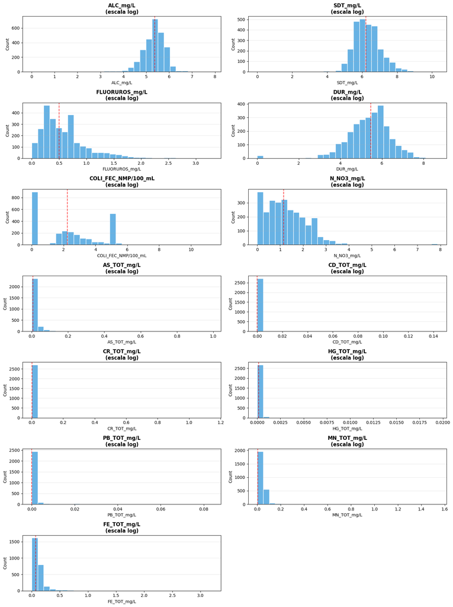

```python
import matplotlib.patches as mpatches
# Correct columns to be plotted
cols_to_plot = [col for col in df.columns if col != 'SEMÁFORO' and col != 'CONTAMINANTES' and col != 'ESTADO']

fig, axes = plt.subplots(nrows=7, ncols=2, figsize=(15, 20))
axes = axes.flatten()

for idx, col in enumerate(cols_to_plot):
    data = df[col].dropna()

    # Detect log_scale
    rango = data.max() / (data.min() + 1e-9) if data.min() >= 0 else None
    usar_log = rango is not None and rango > 100

    vals = np.log1p(data) if usar_log else data
    color = '#3498db' if usar_log else '#2ecc71'

    sns.histplot(data=vals, bins=30, color=color, edgecolor='white', ax=axes[idx], kde=False)

    titulo = f'{col}\n(escala log)' if usar_log else col
    axes[idx].set_title(titulo, fontweight='bold')

    # Median line
    median_val = np.log1p(data.median()) if usar_log else data.median()
    axes[idx].axvline(median_val, color='red', linestyle='--', linewidth=1.5, alpha=0.7)

    axes[idx].grid(axis='y', alpha=0.3)

# Hide empty subplots
for j in range(idx + 1, len(axes)):
    axes[j].set_visible(False)

# Legend
patch_log = mpatches.Patch(color='#3498db', label='Escala log (rango amplio)')
patch_lin = mpatches.Patch(color='#2ecc71', label='Escala lineal')
plt.legend(handles=[patch_log, patch_lin], loc='upper right')
plt.tight_layout()
plt.show()
```

## 5. Features vs. Target: Which parameters distinguish water quality?

Boxplots by traffic-light category are the most relevant visualization for modeling: they allow us to visually see which variables have the greatest discriminative power among the three classes. If a variable shows no difference between GREEN, YELLOW, and RED, it will likely contribute little to the model.

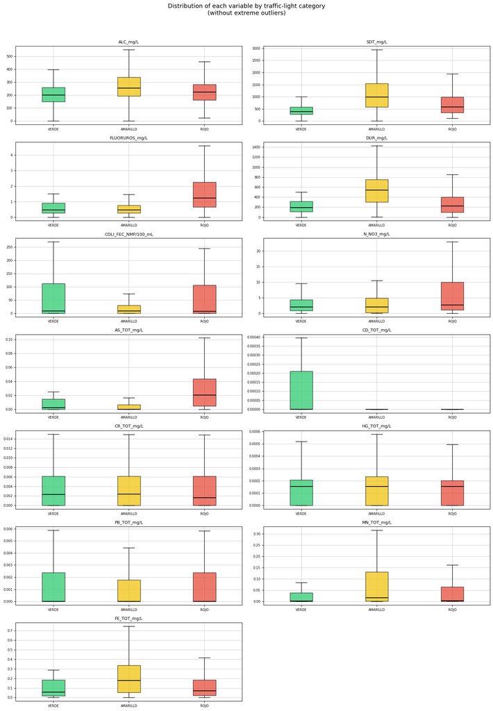

```python
# Settings
cols_to_plot = [col for col in df.columns if col != 'SEMÁFORO' and col != 'CONTAMINANTES' and col != 'ESTADO']
ORDEN_SEMAFORO = ['VERDE', 'AMARILLO', 'ROJO']
COLORS_SEMAFORO = {'VERDE': '#2ecc71', 'AMARILLO': '#f1c40f', 'ROJO': '#e74c3c'}
colores_box = [COLORS_SEMAFORO[c] for c in ORDEN_SEMAFORO]

# Readable names
NOMBRES_LEGIBLES = {col: col for col in cols_to_plot}

# Create subplots
n_cols = 2
n_rows = math.ceil(len(cols_to_plot) / n_cols)
fig, axes = plt.subplots(n_rows, n_cols, figsize=(15, n_rows*3))
axes = axes.flatten()

# Loop through columns
for i, col in enumerate(cols_to_plot):
    data_plot = df[[col, 'SEMÁFORO']].dropna()

    # Get data per group
    grupos = [data_plot[data_plot['SEMÁFORO'] == s][col].values for s in ORDEN_SEMAFORO]

    # Create boxplot manually
    bp = axes[i].boxplot(
        grupos,
        patch_artist=True,
        tick_labels=ORDEN_SEMAFORO,
        showfliers=False,
        medianprops=dict(color='black', linewidth=1.5)
    )

    # Set box colors
    for patch, color in zip(bp['boxes'], colores_box):
        patch.set_facecolor(color)
        patch.set_alpha(0.75)

    # Axes formatting
    axes[i].set_title(NOMBRES_LEGIBLES[col], fontsize=9)
    axes[i].tick_params(axis='x', labelsize=7)
    axes[i].tick_params(axis='y', labelsize=7)

    # Grids
    axes[i].grid(axis='both', linestyle='-', linewidth=0.7, alpha=0.7)

# Hide empty axes if any
for j in range(i + 1, len(axes)):
    axes[j].set_visible(False)

plt.suptitle(
    'Distribution of each variable by traffic-light category\n(without extreme outliers)',
    fontsize=13, y=1.02
)
plt.tight_layout()
plt.show()
```

## 7. Correlation Between Variables

We identified which pairs of variables measure related phenomena. A high correlation between predictors (multicollinearity) is especially relevant for Logistic Regression, which assumes a certain level of independence among input variables.

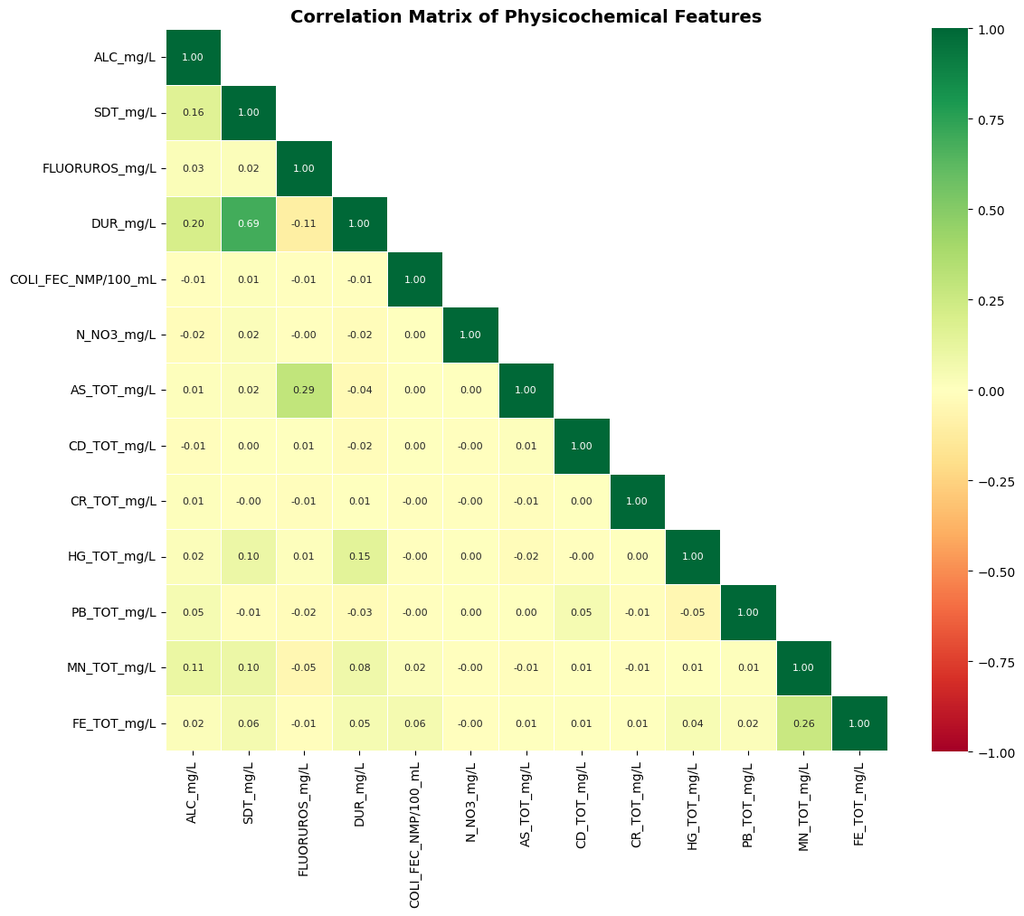

```python
# Get columns excluding 'SEMÁFORO'
cols_to_plot = [col for col in df.columns if col != 'SEMÁFORO' and col != 'CONTAMINANTES' and col != 'ESTADO']

# Calculate correlation matrix
corr_matrix = df[cols_to_plot].corr()

# Create mask for upper triangle (optional, remove if you don't want it)
mask = np.triu(np.ones_like(corr_matrix, dtype=bool), k=1)

# Create the heatmap
fig, ax = plt.subplots(figsize=(12, 10))
sns.heatmap(
    corr_matrix,
    mask=mask,
    cmap='RdYlGn',
    center=0,
    vmin=-1, vmax=1,
    annot=True, fmt='.2f',
    linewidths=0.5,
    square=True,
    ax=ax,
    annot_kws={'size': 8}
)

plt.title('Correlation Matrix of Physicochemical Features', fontsize=14, fontweight='bold')
plt.tight_layout()
plt.show()
```

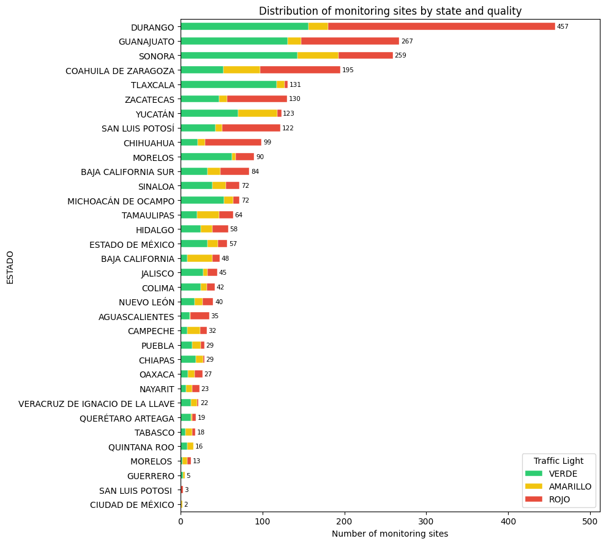

```python
# Group data by state and traffic-light category,
# count occurrences, and pivot into a table format
estado_sem = df.groupby(['ESTADO', 'SEMÁFORO']).size().unstack(fill_value=0)

# Ensure all traffic-light categories exist as columns,
# even if some are missing in the dataset
for col in ORDEN_SEMAFORO:
    if col not in estado_sem.columns:
        estado_sem[col] = 0

# Reorder columns according to the desired traffic-light order
estado_sem = estado_sem[ORDEN_SEMAFORO]

# Compute total monitoring sites per state
estado_sem['TOTAL'] = estado_sem.sum(axis=1)

# Sort states from lowest to highest total
estado_sem = estado_sem.sort_values('TOTAL', ascending=True)

# Create figure and axis
fig, ax = plt.subplots(figsize=(10, 9))

# Plot horizontal stacked bar chart
estado_sem[ORDEN_SEMAFORO].plot(
    kind='barh', stacked=True, ax=ax,
    color=[COLORS_SEMAFORO[c] for c in ORDEN_SEMAFORO],  # color per category
    edgecolor='white', linewidth=0.3  # subtle borders between segments
)

# Add total labels at the end of each bar
for i, (idx, row) in enumerate(estado_sem.iterrows()):
    ax.text(row['TOTAL'] + 2, i, f"{int(row['TOTAL'])}", va='center', fontsize=7.5)

# Axis labels and title
ax.set_xlabel('Number of monitoring sites')
ax.set_title('Distribution of monitoring sites by state and quality')

# Legend configuration
ax.legend(title='Traffic Light', loc='lower right')

# Adjust x-axis limit to leave space for labels
ax.set_xlim(0, estado_sem['TOTAL'].max() * 1.12)

# Improve layout to avoid overlaps
plt.tight_layout()

# Display plot
plt.show()
```

## 9. Encode Target Variable

We map the string labels to integers so scikit-learn can work with them:

| Label | Encoded |
| --- | --- |
| VERDE | 0 |
| AMARILLO | 1 |
| ROJO | 2 |

```python
# Establish a numerical value to the target variable {'VERDE': 0, 'AMARILLO': 1, 'ROJO': 2}
mapping = {'VERDE': 0, 'AMARILLO': 1, 'ROJO': 2}
df['SEMÁFORO'] = df['SEMÁFORO'].map(mapping)
df = df.drop(["CONTAMINANTES", 'ESTADO'], axis=1)  # df
df.head()
```

|  | ALC_mg/L | SDT_mg/L | FLUORUROS_mg/L | DUR_mg/L | COLI_FEC_NMP/100_mL | N_NO3_mg/L | AS_TOT_mg/L | CD_TOT_mg/L | CR_TOT_mg/L | HG_TOT_mg/L | PB_TOT_mg/L | MN_TOT_mg/L | FE_TOT_mg/L | SEMÁFORO |
| --- | --- | --- | --- | --- | --- | --- | --- | --- | --- | --- | --- | --- | --- | --- |
| 0 | 139.700 | 562.4 | 0.820 | 505.8000 | 97.0 | 0.591000 | 0.000000 | 0.0 | 0.00000 | 0.000000 | 0.00000 | 0.032000 | 0.01100 | 1 |
| 1 | 148.645 | 184.6 | 0.520 | 132.0000 | 0.0 | 0.315762 | 0.011667 | 0.0 | 0.00000 | 0.000116 | 0.00000 | 0.000000 | 0.00425 | 0 |
| 2 | 205.020 | 378.0 | 0.430 | 230.0000 | 10.0 | 3.182000 | 0.012767 | 0.0 | 0.00230 | 0.000000 | 0.00827 | 0.013150 | 0.19075 | 0 |
| 3 | 229.140 | 322.0 | 0.500 | 221.7114 | 0.0 | 3.843000 | 0.012533 | 0.0 | 0.00210 | 0.000000 | 0.00000 | 0.001105 | 0.01655 | 0 |
| 4 | 168.400 | 239.6 | 0.566 | 152.0000 | 0.0 | 0.156885 | 0.012567 | 0.0 | 0.00175 | 0.000000 | 0.00000 | 0.104700 | 0.00450 | 0 |

## 10. Train / Test Split

We separate features (`X`) from the target (`y`) and split into 70% training and 30% test sets.

```python
# Entry variable
X = df.drop(columns=["SEMÁFORO"])

# Target variable
y = df["SEMÁFORO"]

X.shape, y.shape
```

```
((2728, 13), (2728,))
```

```python
from sklearn.model_selection import train_test_split

X_train, X_test, y_train, y_test = train_test_split(
    X, y,
    test_size=0.3,
    random_state=42
)

print("Train shapes:", X_train.shape, y_train.shape)
print("Test shapes: ", X_test.shape,  y_test.shape)
```

```
Train shapes: (1909, 13) (1909,)
Test shapes:  (819, 13) (819,)
```

```python
X_train.iloc[1, :]
```

|  | 1048 |
| --- | --- |
| ALC_mg/L | 271.600000 |
| SDT_mg/L | 1984.000000 |
| FLUORUROS_mg/L | 0.882000 |
| DUR_mg/L | 1679.600000 |
| COLI_FEC_NMP/100_mL | 8.788050 |
| N_NO3_mg/L | 2.462000 |
| AS_TOT_mg/L | 0.000000 |
| CD_TOT_mg/L | 0.000000 |
| CR_TOT_mg/L | 0.001844 |
| HG_TOT_mg/L | 0.000210 |
| PB_TOT_mg/L | 0.000000 |
| MN_TOT_mg/L | 0.000399 |
| FE_TOT_mg/L | 0.091163 |

**dtype:** float64

```python
y_train.iloc[1]
```

```
np.int64(1)
```

# 11. Predictive Models

The following blocks revisits the dataset incorporating predictive models:

### Model: Decision Tree

We train a Decision Tree classifier with `max_depth=6` to keep the model interpretable and avoid overfitting to the training data.

```python
from sklearn.tree import DecisionTreeClassifier

# Define the model: Decision Tree
tree = DecisionTreeClassifier(max_depth=6,             # Maximum depth of the tree: limits how many splits are made (controls overfitting; deeper = more complex)
                              random_state=42,         # Seed for reproducibility (ensures same splits across runs)
                              class_weight='balanced') # Adjusts weights inversely proportional to class frequencies (helps with imbalanced datasets)

# Train the model
tree.fit(X_train, y_train)
```

```
DecisionTreeClassifier(class_weight='balanced', max_depth=6, random_state=42)
```

#### Evaluation

We evaluate the model on both the training and test sets. A small gap between the two accuracy scores indicates the model generalizes well without overfitting.

```python
from sklearn.metrics import accuracy_score

# Training predictions
y_train_pred = tree.predict(X_train)

# Test predictions
y_pred = tree.predict(X_test)

print("Train accuracy:", accuracy_score(y_train, y_train_pred))
print("Test accuracy: ", accuracy_score(y_test,  y_pred))
```

```
Train accuracy: 0.9392352016762703
Test accuracy:  0.9413919413919414
```

```python
from sklearn.metrics import classification_report

print(classification_report(y_test, y_pred, target_names=['VERDE', 'AMARILLO', 'ROJO']))
```

```
              precision    recall  f1-score   support

       VERDE       0.90      1.00      0.95       362
    AMARILLO       0.95      0.85      0.90       145
        ROJO       1.00      0.92      0.96       312

    accuracy                           0.94       819
   macro avg       0.95      0.92      0.93       819
weighted avg       0.95      0.94      0.94       819
```

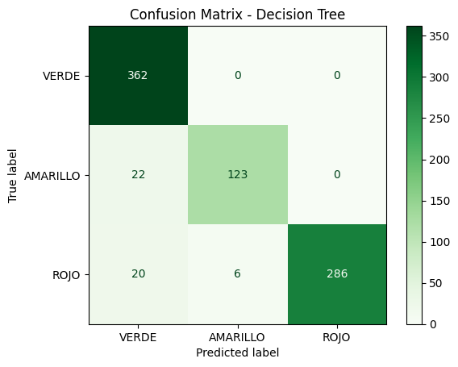

```python
from sklearn.metrics import ConfusionMatrixDisplay
# Confusion Matrix
ConfusionMatrixDisplay.from_estimator(
    tree,
    X_test,
    y_test,
    display_labels=['VERDE', 'AMARILLO', 'ROJO'],
    cmap="Greens"
)
plt.title("Confusion Matrix - Decision Tree")
plt.show()
```

### Logistic Regression

```python
# StandardScaler — fit only on train to avoid data leakage
from sklearn.preprocessing import StandardScaler
scaler = StandardScaler()
X_train_scaled = scaler.fit_transform(X_train)
X_test_scaled  = scaler.transform(X_test)
```

```python
from sklearn.linear_model import LogisticRegression

log_reg = LogisticRegression(max_iter=1000,     # Maximum number of iterations for the solver to converge (higher = more time to find optimal solution)
                             random_state = 42) # Seed for reproducibility

log_reg.fit(X_train_scaled, y_train)
```

```
LogisticRegression(max_iter=1000, random_state=42)
```

```python
y_pred_log = log_reg.predict(X_test_scaled)
```

#### Evaluation

We evaluate the model on both the training and test sets. A small gap between the two accuracy scores indicates the model generalizes well without overfitting.

```python
# Training predictions
y_train_pred_log = log_reg.predict(X_train_scaled)

# Test predictions
y_pred_log = log_reg.predict(X_test_scaled)

print("Train accuracy:", accuracy_score(y_train, y_train_pred_log))
print("Test accuracy: ", accuracy_score(y_test,  y_pred_log))
```

```
Train accuracy: 0.8145625982189628
Test accuracy:  0.8229548229548229
```

```python
print(classification_report(y_test, y_pred_log, target_names=['VERDE', 'AMARILLO', 'ROJO']))
```

```
              precision    recall  f1-score   support

       VERDE       0.80      0.91      0.85       362
    AMARILLO       0.86      0.67      0.75       145
        ROJO       0.84      0.79      0.82       312

    accuracy                           0.82       819
   macro avg       0.83      0.79      0.81       819
weighted avg       0.83      0.82      0.82       819
```

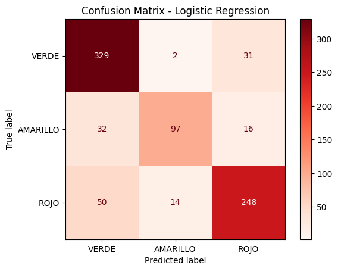

```python
ConfusionMatrixDisplay.from_estimator(
    log_reg,
    X_test_scaled,
    y_test,
    display_labels=['VERDE', 'AMARILLO', 'ROJO'],
    cmap="Reds"
)
plt.title("Confusion Matrix - Logistic Regression")
plt.show()
```

### Supported Vector Machine

```python
from sklearn.svm import SVC

svm = SVC(
    C            = 1000,       # Regularization parameter: high value -> tries to classify all training points correctly (less margin, risk of overfitting)
    gamma        = 0.01,       # Kernel coefficient for RBF: controls how far the influence of a single point reaches (low = smoother decision boundary)
    kernel       = 'rbf',      # Radial Basis Function kernel: good for non-linear relationships
    class_weight = 'balanced', # Adjusts weights inversely proportional to class frequencies (helps with imbalanced datasets)
    random_state = 42,         # Seed for reproducibility
)

# Training model
svm.fit(X_train_scaled, y_train)
```

```
SVC(C=1000, class_weight='balanced', gamma=0.01, random_state=42)
```

```python
y_pred_svm = svm.predict(X_test_scaled)
```

#### Evaluation

We evaluate the model on both the training and test sets. A small gap between the two accuracy scores indicates the model generalizes well without overfitting.

```python
# Training predictions
y_train_pred_svm = svm.predict(X_train_scaled)

# Test predictions
y_pred_svm = svm.predict(X_test_scaled)

print("Train accuracy:", accuracy_score(y_train, y_train_pred_svm))
print("Test accuracy: ", accuracy_score(y_test,  y_pred_svm))
```

```
Train accuracy: 0.927187008905186
Test accuracy:  0.8913308913308914
```

```python
print(classification_report(y_test, y_pred_svm, target_names=['VERDE', 'AMARILLO', 'ROJO']))
```

```
              precision    recall  f1-score   support

       VERDE       0.92      0.92      0.92       362
    AMARILLO       0.79      0.87      0.83       145
        ROJO       0.92      0.87      0.89       312

    accuracy                           0.89       819
   macro avg       0.87      0.89      0.88       819
weighted avg       0.89      0.89      0.89       819
```

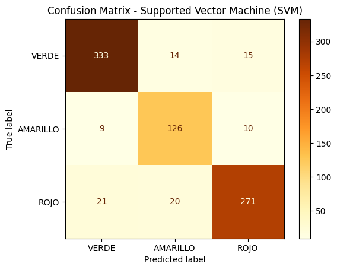

```python
ConfusionMatrixDisplay.from_estimator(
    svm,
    X_test_scaled,
    y_test,
    display_labels=['VERDE', 'AMARILLO', 'ROJO'],
    cmap="YlOrBr"
)
plt.title("Confusion Matrix - Supported Vector Machine (SVM)")
plt.show()
```